# Chapter 9 Assignment

Joe Dickerson

2025-11-02

```r
library(ISLR2)
library(e1071)
data(OJ)
```

Question 8

1. Create a training set containing a random sample of 800 observations, and a test set containing the remaining observations.

```r
set.seed(1)

seq <- sample(1:nrow(OJ), 800)

train <- OJ[seq, ]
test <- OJ[-seq, ]
```

2. Fit a support vector classifier to the training data using cost = 0.01, with Purchase as the response and the other variables as predictors. Use the summary() function to produce summary statistics, and describe the results obtained.

There are 615 support vectors used in the model, splitting the points by 309 and 306 respectively between Citrus Hill and Minute Maid.

```r
svmfit <- svm(Purchase ~ ., data = train, kernel = "linear", cost = 0.01, scale = FALSE)

summary(svmfit)
```

```
##
## Call:
## svm(formula = Purchase ~ ., data = train, kernel = "linear", cost = 0.01,
##     scale = FALSE)
##
##
## Parameters:
##    SVM-Type:  C-classification
##  SVM-Kernel:  linear
##        cost:  0.01
##
## Number of Support Vectors:  615
##
##  ( 309 306 )
##
##
## Number of Classes:  2
##
## Levels:
##  CH MM
```

3. What are the training and test error rates?

The training error rate is 0.456 and the test error rate is 0.233.

```r
yhat <- predict(svmfit, newdata = test, type = "class")

mean(yhat != train$Purchase)
```

```
## [1] 0.45625
```

```r
table(yhat, test$Purchase)
```

```
##
## yhat  CH  MM
##   CH 148  43
##   MM  20  59
```

```r
(20 + 43) / (148 + 59 + 20 + 43)
```

```
## [1] 0.2333333
```

4. Use the tune() function to select an optimal cost. Consider values in the range 0.01 to 10.

```r
set.seed(1)

tune.out <- e1071::tune(svm, Purchase ~ ., data = train, kernel = "linear", ranges = list(cost = c(.01, 1, 2, 4, 6, 8, 10)))

summary(tune.out)
```

```
##
## Parameter tuning of 'svm':
##
## - sampling method: 10-fold cross validation
##
## - best parameters:
##  cost
##     4
##
## - best performance: 0.17
##
## - Detailed performance results:
##    cost   error dispersion
## 1  0.01 0.17625 0.02853482
## 2  1.00 0.17500 0.02946278
## 3  2.00 0.17250 0.02874698
## 4  4.00 0.17000 0.02958040
## 5  6.00 0.17500 0.03333333
## 6  8.00 0.17375 0.03197764
## 7 10.00 0.17375 0.03197764
```

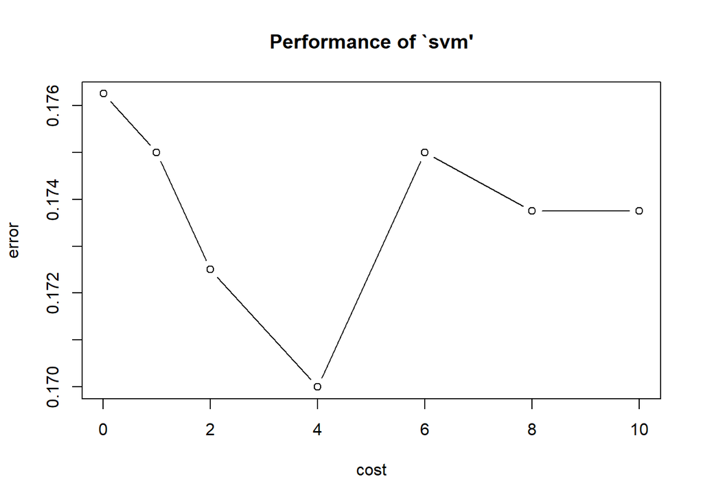

```r
plot(tune.out)
```

5. Compute the training and test error rates using this new value for cost.

The training error rate is 0.483, and the test error rate is 0.163. The training error rate is slightly higher, but the test error is lower.

```r
svmfit2 <- svm(Purchase ~ ., data = train, kernel = "linear", cost = 4, scale = FALSE)

summary(svmfit2)
```

```
##
## Call:
## svm(formula = Purchase ~ ., data = train, kernel = "linear", cost = 4,
##     scale = FALSE)
##
##
## Parameters:
##    SVM-Type:  C-classification
##  SVM-Kernel:  linear
##        cost:  4
##
## Number of Support Vectors:  333
##
##  ( 166 167 )
##
##
## Number of Classes:  2
##
## Levels:
##  CH MM
```

```r
yhat2 <- predict(svmfit2, newdata = test, type = "class")

table(yhat2, test$Purchase)
```

```
##
## yhat2  CH  MM
##    CH 155  31
##    MM  13  71
```

```r
mean(yhat2 != train$Purchase)
```

```
## [1] 0.4825
```

```r
(31 + 13) / (155 + 71 + 31 + 13)
```

```
## [1] 0.162963
```

6. Repeat parts (b) through (e) using a support vector machine with a radial kernel. Use the default value for gamma.

Training error rate is 0.394, and test error rate is 0.378. The optimal cost via the tune() function is 1. We refit the model using 1 as the value for cost. The training error rate is then 0.479 and test error rate is 0.185. Again, a higher training error but a lower test error.

```r
svmfit.rad <- svm(Purchase ~ ., data = train, kernel = "radial", cost = 0.01)

summary(svmfit.rad)
```

```
##
## Call:
## svm(formula = Purchase ~ ., data = train, kernel = "radial", cost = 0.01)
##
##
## Parameters:
##    SVM-Type:  C-classification
##  SVM-Kernel:  radial
##        cost:  0.01
##
## Number of Support Vectors:  634
##
##  ( 319 315 )
##
##
## Number of Classes:  2
##
## Levels:
##  CH MM
```

```r
yhat.r <- predict(svmfit.rad, newdata = test, type = "class")

mean(yhat.r != train$Purchase)
```

```
## [1] 0.39375
```

```r
table(yhat.r, test$Purchase)
```

```
##
## yhat.r  CH  MM
##     CH 168 102
##     MM   0   0
```

```r
(102) / (168 + 102)
```

```
## [1] 0.3777778
```

```r
set.seed(1)

tune.r <- e1071::tune(svm, Purchase ~ ., data = train, kernel = "radial", ranges = list(cost = c(.01, 1, 2, 4, 6, 8, 10)))

summary(tune.r)
```

```
##
## Parameter tuning of 'svm':
##
## - sampling method: 10-fold cross validation
##
## - best parameters:
##  cost
##     1
##
## - best performance: 0.17125
##
## - Detailed performance results:
##    cost   error dispersion
## 1  0.01 0.39375 0.04007372
## 2  1.00 0.17125 0.02128673
## 3  2.00 0.17750 0.02188988
## 4  4.00 0.18125 0.02301117
## 5  6.00 0.18000 0.02220485
## 6  8.00 0.18250 0.02648375
## 7 10.00 0.18625 0.02853482
```

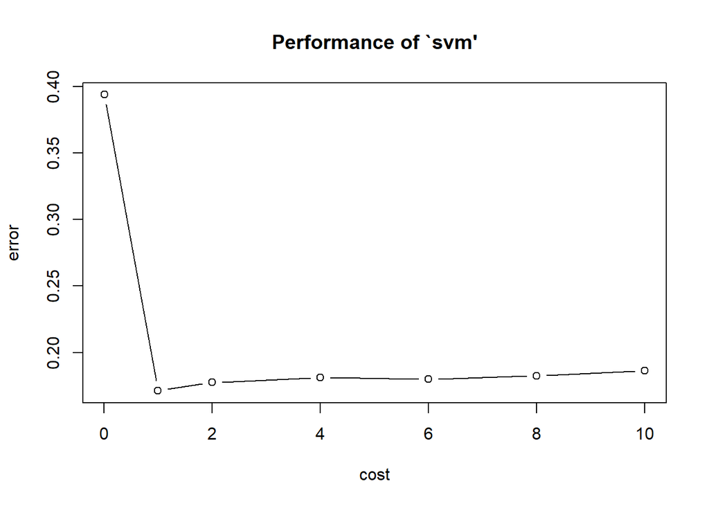

```r
plot(tune.r)
```

```r
svmfit.rad2 <- svm(Purchase ~ ., data = train, kernel = "radial", cost = 1)

yhat.r2 <- predict(svmfit.rad2, newdata = test, type = "class")

mean(yhat.r2 != train$Purchase)
```

```
## [1] 0.47875
```

```r
table(yhat.r2, test$Purchase)
```

```
##
## yhat.r2  CH  MM
##      CH 151  33
##      MM  17  69
```

```r
(17 + 33) / (151 + 69 + 17 + 33)
```

```
## [1] 0.1851852
```

7. Repeat parts (b) through (e) using a support vector machine with a polynomial kernel. Set degree = 2.

```r
svmfit.poly <- svm(Purchase ~ ., data = train, kernel = "polynomial", cost = 0.01, degree = 2)

summary(svmfit.poly)
```

```
##
## Call:
## svm(formula = Purchase ~ ., data = train, kernel = "polynomial",
##     cost = 0.01, degree = 2)
##
##
## Parameters:
##    SVM-Type:  C-classification
##  SVM-Kernel:  polynomial
##        cost:  0.01
##      degree:  2
##      coef.0:  0
##
## Number of Support Vectors:  636
##
##  ( 321 315 )
##
##
## Number of Classes:  2
##
## Levels:
##  CH MM
```

```r
yhat.poly <- predict(svmfit.poly, newdata = test, type = "class")

mean(yhat.poly != train$Purchase)
```

```
## [1] 0.395
```

```r
table(yhat.poly, test$Purchase)
```

```
##
## yhat.poly  CH  MM
##        CH 167  98
##        MM   1   4
```

```r
(98 + 1) / (167 + 4 + 98 + 1)
```

```
## [1] 0.3666667
```

```r
set.seed(1)

tune.poly <- e1071::tune(svm, Purchase ~ ., data = train, kernel = "polynomial", ranges = list(cost = c(.01, 1, 2, 4, 6, 8, 10)))

summary(tune.poly)
```

```
##
## Parameter tuning of 'svm':
##
## - sampling method: 10-fold cross validation
##
## - best parameters:
##  cost
##     1
##
## - best performance: 0.185
##
## - Detailed performance results:
##    cost   error dispersion
## 1  0.01 0.37125 0.03537988
## 2  1.00 0.18500 0.02415229
## 3  2.00 0.19000 0.02188988
## 4  4.00 0.19125 0.02571883
## 5  6.00 0.19000 0.03270236
## 6  8.00 0.19125 0.03120831
## 7 10.00 0.19500 0.03184162
```

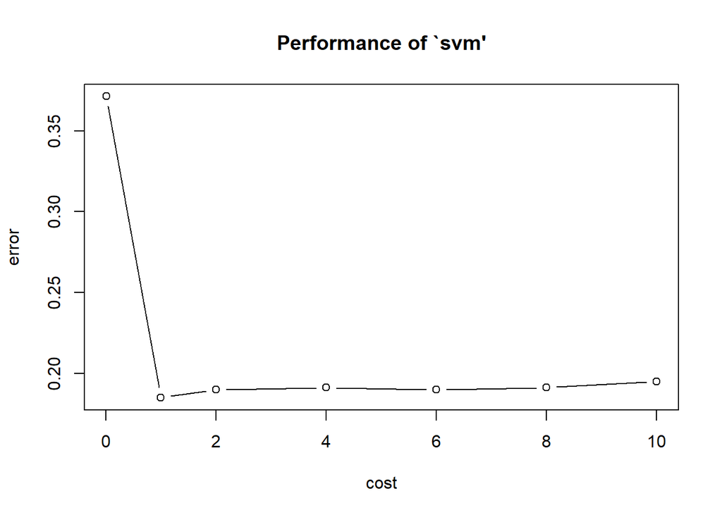

```r
plot(tune.poly)
```

```r
svmfit.poly2 <- svm(Purchase ~ ., data = train, kernel = "polynomial", cost = 1, degree = 2)

yhat.poly2 <- predict(svmfit.poly2, newdata = test, type = "class")

mean(yhat.poly2 != train$Purchase)
```

```
## [1] 0.4575
```

```r
table(yhat.poly2, test$Purchase)
```

```
##
## yhat.poly2  CH  MM
##         CH 153  45
##         MM  15  57
```

```r
(15 + 45) / (153 + 57)
```

```
## [1] 0.2857143
```

8. Overall, which approach seems to give the best results on this data?

It seems that either linear or radial is the best for this data, while polynomial is not as effective. Between linear and radial, it seems linear possesses the lowest test error rate at 0.163 when the cost is set to 4, which might make that the preferred method. Further testing could be done to get a clearer result.